# Network analysis

## Networks in igraph

[Source](http://kateto.net/ruworkshop)

### Create networks

Generate an undirected graph with three edges. The numbers are interpreted as vertex IDs, so the edges are `1–>2`, `2–>3`, `3–>1`.

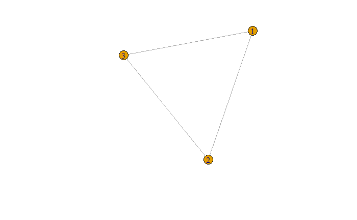

```r
class(g1)
```

```
[1] "igraph"
```

```r
g1
```

```
IGRAPH 2dcce9f U--- 3 3 --
+ edges from 2dcce9f:
[1] 1--2 2--3 1--3
```

Now with 10 vertices, and directed by default:

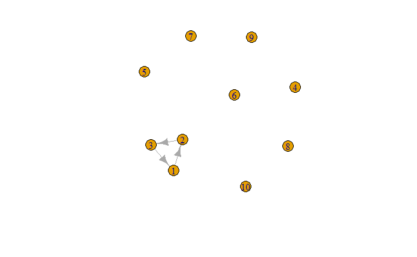

```r
g2
```

```
IGRAPH 72a020a D--- 10 3 --
+ edges from 72a020a:
[1] 1->2 2->3 3->1
```

Named vertices

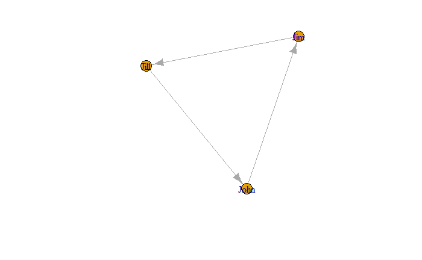

```r
g3
```

```
IGRAPH 94342f5 DN-- 3 3 --
+ attr: name (v/c)
+ edges from 94342f5 (vertex names):
[1] John->Jim  Jim ->Jill Jill->John
```

In named graphs we can specify isolates by providing a list of their names.

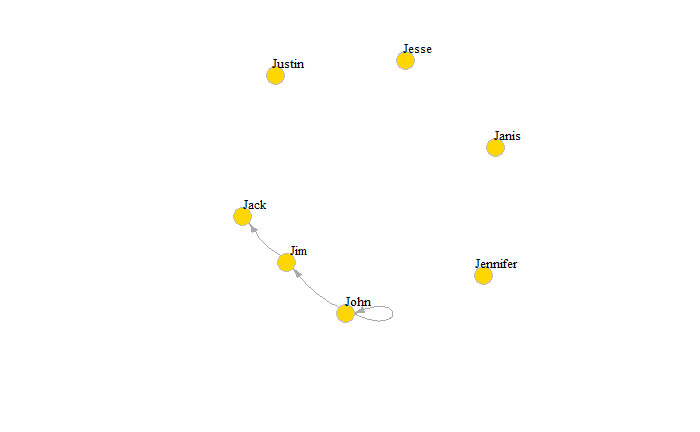

Small graphs can also be generated with a description of this kind: `-` for undirected tie, `+-` or `-+` for directed ties pointing left & right, `++` for a symmetric tie, and `:` for sets of vertices.

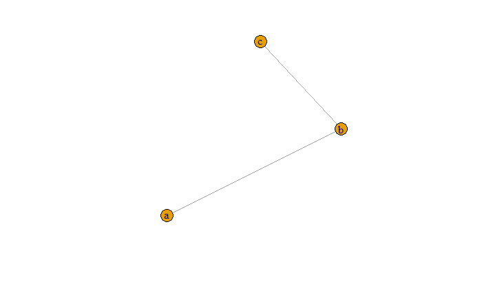

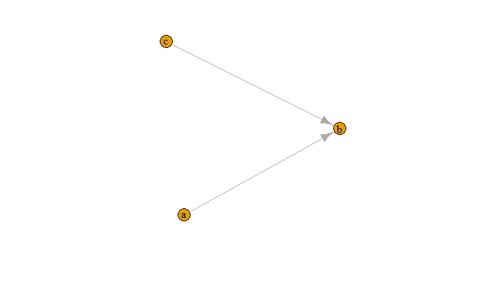

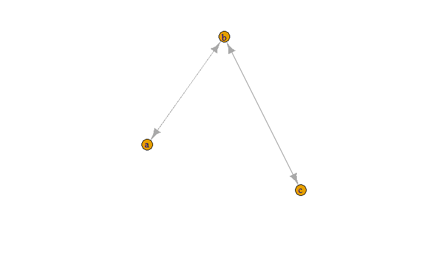

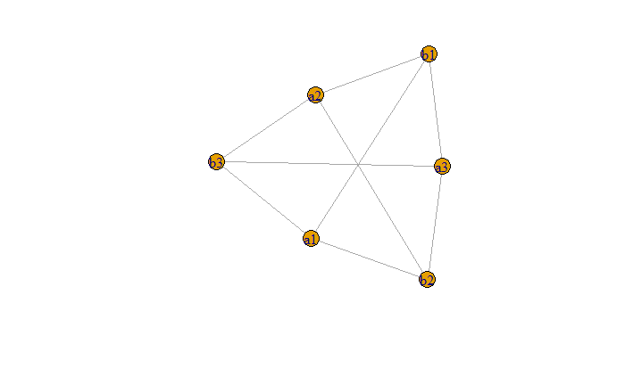

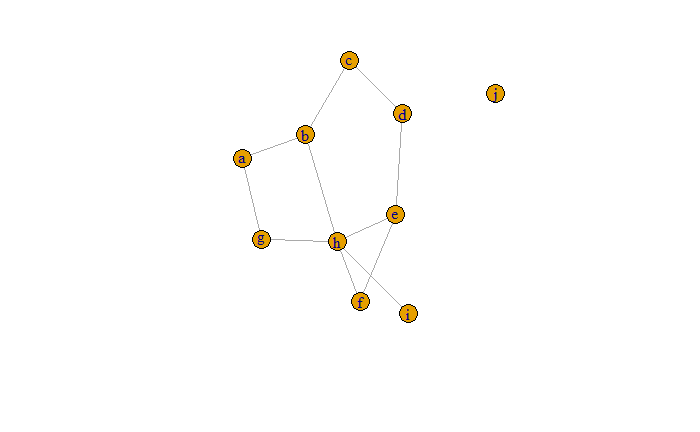

### Edge, vertex, and network attributes

Access vertices and edges

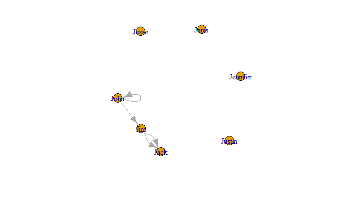

```r
plot(g4)
```

```r
E(g4)
```

```
+ 4/4 edges from baf7d2e (vertex names):
[1] John->Jim  Jim ->Jack Jim ->Jack John->John
```

```r
V(g4)
```

```
+ 7/7 vertices, named, from baf7d2e:
[1] John     Jim      Jack     Jesse    Janis    Jennifer Justin
```

Examine the network matrix

```r
g4[]
```

```
7 x 7 sparse Matrix of class "dgCMatrix"
         John Jim Jack Jesse Janis Jennifer Justin
John        1   1    .     .     .        .      .
Jim         .   .    2     .     .        .      .
Jack        .   .    .     .     .        .      .
Jesse       .   .    .     .     .        .      .
Janis       .   .    .     .     .        .      .
Jennifer    .   .    .     .     .        .      .
Justin      .   .    .     .     .        .      .
```

```r
g4[1,]
```

```
    John      Jim     Jack    Jesse    Janis Jennifer   Justin
       1        1        0        0        0        0        0
```

Add attributes to the network, vertices, or edges

```r
V(g4)$name
```

```
[1] "John"     "Jim"      "Jack"     "Jesse"    "Janis"    "Jennifer" "Justin"
```

```r
edge_attr(g4)
```

```
$`type`
[1] "email" "email" "email" "email"

$weight
[1] 10 10 10 10
```

```r
vertex_attr(g4)
```

```
$`name`
[1] "John"     "Jim"      "Jack"     "Jesse"    "Janis"    "Jennifer" "Justin"

$gender
[1] "male"   "male"   "male"   "male"   "female" "female" "male"
```

```r
graph_attr(g4)
```

```
named list()
```

Another way to set attributes (you can similarly use `set_edge_attr()`, `set_vertex_attr()`, etc.):

```r
graph_attr_names(g4)
```

```
[1] "name"      "something"
```

```r
graph_attr(g4, "name")
```

```
[1] "Email Network"
```

```r
graph_attr(g4)
```

```
$`name`
[1] "Email Network"

$something
[1] "A thing"
```

```r
graph_attr(g4)
```

```
$`name`
[1] "Email Network"
```

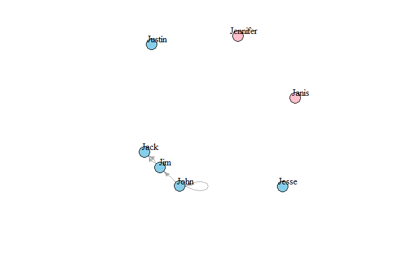

The graph `g4` has two edges going from `Jim` to `Jack`, and a loop from `John` to himself. We can simplify our graph to remove loops & multiple edges between the same nodes. Use `edge.attr.comb` to indicate how edge attributes are to be combined - possible options include `sum`, `mean`, `prod` (product), `min`, `max`, `first`/`last` (selects the first/last edge’s attribute). Option `ignore` says the attribute should be disregarded and dropped.

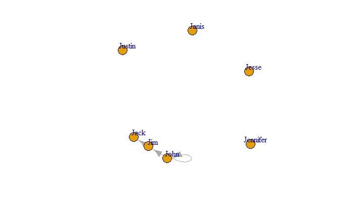

```r
g4s
```

```
IGRAPH ee5ef56 DNW- 7 3 -- Email Network
+ attr: name (g/c), name (v/c), gender (v/c), weight (e/n)
+ edges from ee5ef56 (vertex names):
[1] John->John John->Jim  Jim ->Jack
```

The description of an igraph object starts with up to four letters:

1. `D` or `U`, for a directed or undirected graph
2. `N` for a named graph (where nodes have a `name` attribute)
3. `W` for a weighted graph (where edges have a `weight` attribute)
4. `B` for a bipartite (two-mode) graph (where nodes have a `type` attribute)

The two numbers that follow (`7 3`) refer to the number of nodes and edges in the graph. The description also lists node & edge attributes, for example:

- (`g/c`) - graph-level character attribute
- (`v/c`) - vertex-level character attribute
- (`e/n`) - edge-level numeric attribute

### Specific graph and graph models

**Empty graph**

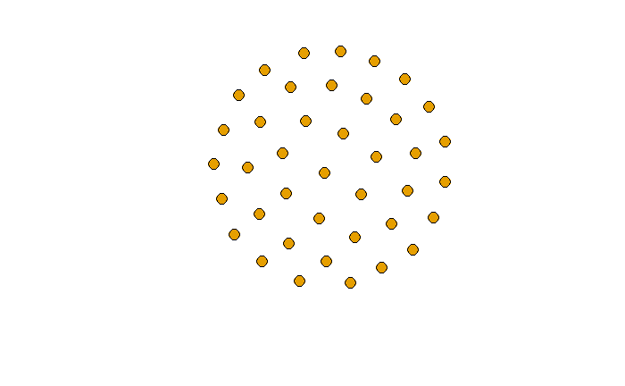

**Full graph**

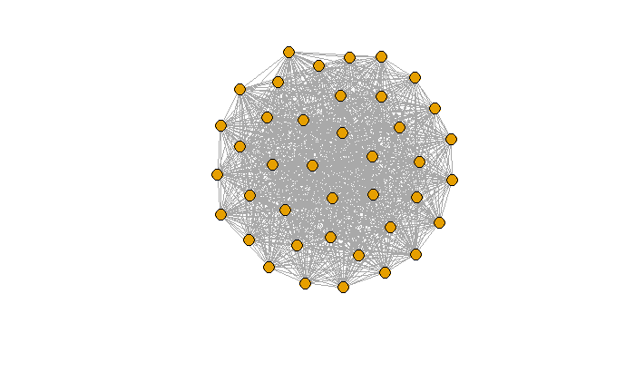

**Simple star graph**

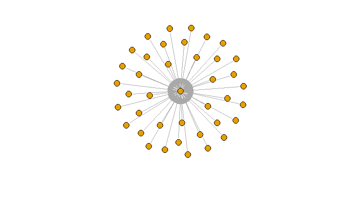

**Tree graph**

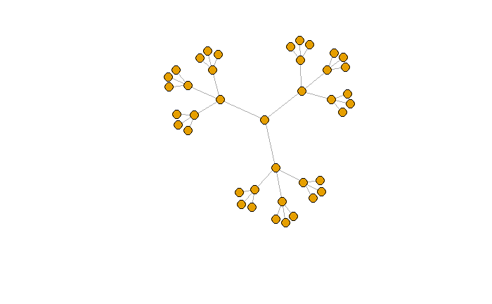

**Ring Graph**

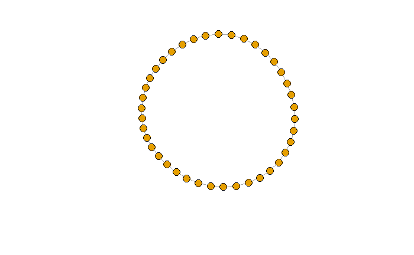

**Erdos-Renyi random graph model** `n` is number of nodes, `m` is the number of edges

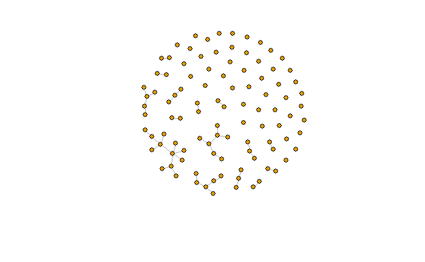

**Watts-Strogatz small-world model** Creates a lattice (with `dim` dimensions and `size` nodes across dimension) and rewires edges randomly with probability `p`. The neighborhood in which edges are connected is `nei`. You can allow loops and multiple edges.

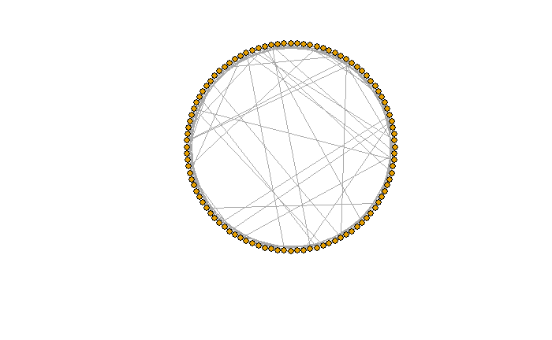

**Barabasi-Albert preferential attachment model for scale-free graphs** `n` is number of nodes, `power` is the power of attachment (1 is linear); `m` is the number of edges added on each time step

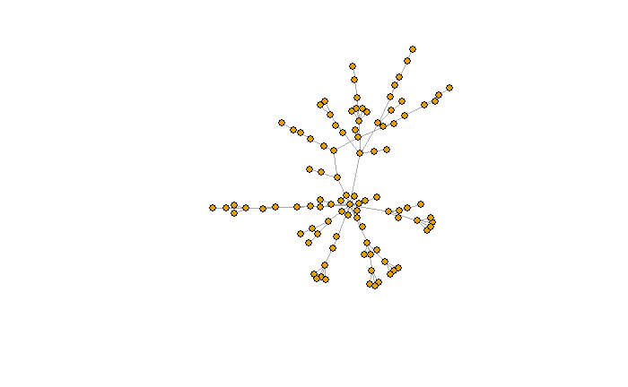

**Notable historical graphs**

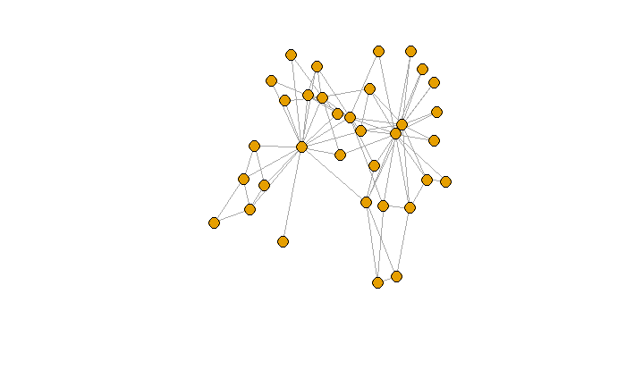

**Rewiring a graph** `each_edge()` is a rewiring method that changes the edge endpoints uniformly randomly with a probability `prob`.

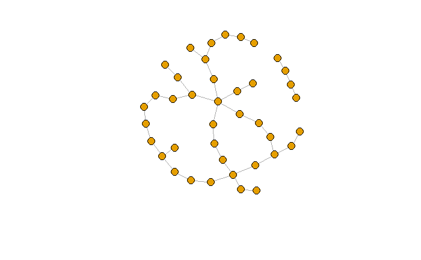

Rewire to connect vertices to other vertices at a certain distance.

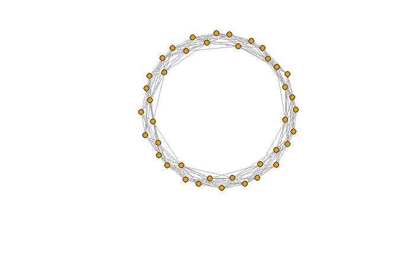

Combine graphs (disjoint union, assuming separate vertex sets) `%du%`

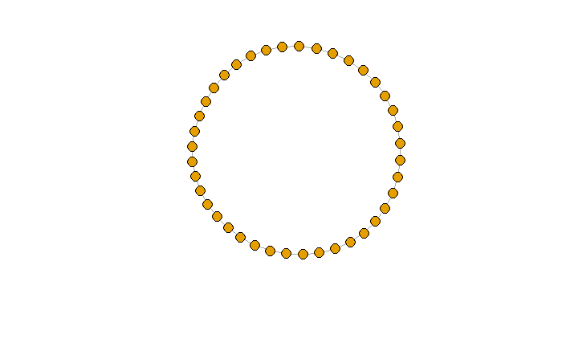

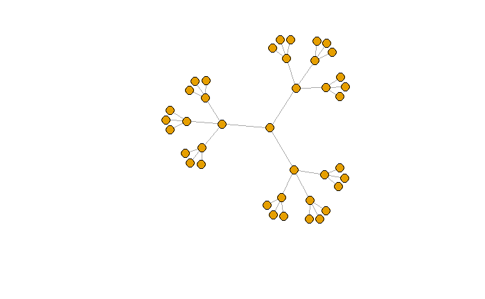

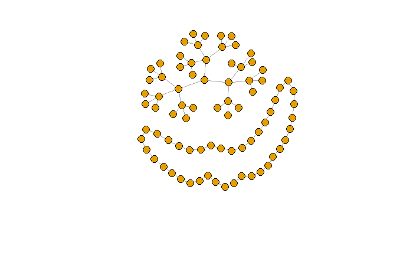